# Intro to Bootstrap

Edward Vytlacil

# Application: Mincer Wage Equation

## Application: Mincer Wage Equation

Mincer wage equation ([Mincer 1958](https://www.jstor.org/stable/1827422?seq=1)):

$$\ln(wage_i) = \beta_0
+ \beta_1 \text{exp}_i + \beta_2 \text{exp}_i^2 + e_i$$

- For ease of exposition, dropping education.

## Application: Mincer Wage Equation

Mincer wage equation ([Mincer 1958](https://www.jstor.org/stable/1827422?seq=1)):

$$\ln(wage_i) = \beta_0
+ \beta_1 \text{exp}_i + \beta_2 \text{exp}_i^2 + e_i$$

- Average marginal effect of experience:
  $$\theta_1 = \beta_1 + 2 \cdot \beta_2 \cdot \mathbb{E}(\text{exp}),$$
- Assuming $\beta_1>0, \beta_2 < 0$, experience level that maximizes predicted log wage:
  $$\theta_2 = -\frac{\beta_1}{2 \beta_2}.$$

## Application: Mincer Wage Equation

- Let $\widehat \beta_{1,n}, \widehat \beta_{2,n}$ denote OLS estimators, and $\overline{\text{exp}}_{n}$ denote sample mean of experience.
- Estimate avg. marginal effect of exp by *non-linear* function of $(\widehat \beta_{1,n}, \widehat \beta_{2,n}, \overline{\text{exp}}_{n})$:
  $$\widehat \theta_{1,n} = \widehat \beta_{1,n} + 2 \cdot \widehat \beta_{2,n} \cdot \overline{\text{exp}}_{n},$$
- Estimate exp level that maximizes predicted log wage by *non-linear* function of $(\widehat \beta_{1,n}, \widehat \beta_{2,n})$:
  $$\widehat \theta_{2,n} =-\frac{\widehat \beta_{1,n}}{2 \widehat \beta_{2,n}}.$$
- How do we compute standard errors, construct confidence intervals, and conduct hypothesis tests for nonlinear functions of estimated coefficients?

# Delta Method vs Bootstrap

## Traditional approach: [Delta Method](https://en.wikipedia.org/wiki/Delta_method).

- Based on a first-order Taylor/mean-value approximation and the asymptotic normality of the underlying estimator.
- Limitations:
  - only justified asymptotically,
  - sometimes provides poor approximation,
  - derivations using the delta method can be tedious and prone to algebraic error.

## Traditional approach: Delta Method (cont’d).

- Advantages:
  - Closed-form expression for the asymptotic variance provides **direct insight into precision**: inspecting the formula reveals which parameters drive (un)certainty.
  - If a parameter appears in the **denominator** of the limit variance, this signals that precision will be poor when that parameter is close to zero.
  - Example: for $\widehat\theta_{2,n} = -\widehat\beta_{1,n}/(2\widehat\beta_{2,n})$, the limit variance involves $1/\beta_2^2$ and $1/\beta_2^4$. The formula immediately warns you that inference will be unreliable when $\beta_2 \approx 0$.

## Bootstrap principle

- In MC simulations (previous lectures), we studied the sampling distribution of an estimator by *repeatedly drawing from a known DGP* $F$ and computing the statistic on each draw. In the notation from the MC slides, we use MC draws from known $F$ to approximate $G_n(\cdot, F).$
- Problem: we don’t know $F$.
- Bootstrap idea: replace $F$ with the empirical CDF $\widehat F_{n}$, defined as
  $$\widehat F_{n}(t) = \frac{1}{n}\sum_{i=1}^n \mathbf{1}\{W_i \le t\},$$
  and run the *same MC simulation* drawing from $\widehat F_{n}$. In the notation from the MC slides, we use MC draws from realized $\widehat F_n$ to approximate $G_n(\cdot, \widehat F_n),$ and use $G_n(\cdot,\widehat F_n)$ to approximate $G_n(\cdot, F).$
- Drawing from $\widehat F_{n}$ $=$ *resampling with replacement* from the original sample.

## Why Should This Work? Glivenko–Cantelli

**Theorem (Glivenko–Cantelli).** If $W_1, W_2, \ldots$ are i.i.d. from $F$, then
$$\sup_t | \widehat F_{n}(t) - F(t) | \xrightarrow{a.s.} 0.$$

- Consequence: $G_n(\cdot, \widehat F_n) \approx G_n(\cdot, F)$ for large $n$ — provided the functional depends on $F$ in a suitably smooth way.

## Bootstrap: Basic Principle

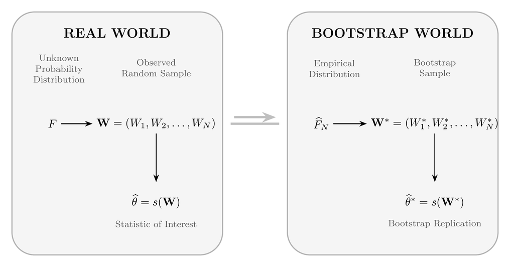

## Bootstrap Method

- Limitations:
  - only justified asymptotically,
  - sometimes provides poor approximation,
  - can be computationally intensive,
  - black-box, does not provide direct insight into what drives precision.
- Advantages:
  - Can bypass derivations, complicated formulas. Less tedious to implement. Removes chance of algebraic error in derivations.
  - Sometimes provides better approximation than delta method.

## Bootstrap Implementation

- The bootstrap is a MC simulation where the DGP is $\widehat F_{n}$.
- Everything we learned about MC simulations carries over:
  - user-defined function for estimator, `replicate` or `boot` to generate $B$ replications, histograms and summary statistics to examine the distribution.

## Rest of This Lecture

- First, we describe the bootstrap algorithm in detail:
  - standard errors,
  - estimate of bias,
  - normal-approximation CI,
  - percentile CI.
- Then, we cover the theory of the bootstrap:
  - bootstrap consistency,
  - when distribution consistency does and does not imply moment convergence,
  - when the bootstrap fails.

## Next Lecture

- Application to Mincer wage regression, implementation in R.
- Bootstrap hypothesis testing.
- Wild bootstrap.

# Bootstrap Algorithm

## Sample and Estimator

- Suppose $\mathbf{W} = (W_1,W_2,...,W_{n})$ is observed sample
  - e.g., $W_i = (Y_i,X_i)$ in regression context.
- Estimator $\widehat \theta_{n} = s(\mathbf{W})$
  - expressing estimator as function of data, rule for how to use data to compute estimate.
  - in our application, $\widehat \theta_{n}$ is an estimator of average marginal effect of experience or of experience level that maximizes predicted log wage.

## Bootstrap algorithm

Bootstrap Samples

Bootstrap Replications

- Create $B$ bootstrap samples, each constructed by drawing from original sample with replacement $n$ times.

$$\begin{align}
\mathbf{W}^{*1} & = (W^{*1}_1,W^{*1}_2,…,W^{*1}_{n}) ~\Rightarrow \widehat \theta_n^*(1)=s(\mathbf{W}^{*1}) \\
\mathbf{W}^{*2} & = (W^{*2}_1,W^{*2}_2,…,W^{*2}_{n}) ~ \Rightarrow \widehat \theta_n^*(2)=s(\mathbf{W}^{*2}) \\
& \qquad \qquad \quad ~~~\vdots \qquad \qquad \qquad ~~~ \vdots \\
\mathbf{W}^{*B} & = (W^{*B}_1,W^{*B}_2,…,W^{*B}_{n}) \Rightarrow \widehat \theta_n^*(B)=s(\mathbf{W}^{*B}). \\
\end{align}$$

- Compute bootstrap replication on each bootstrap sample, $\widehat \theta_n^*(b) = s(\mathbf{W}^{*b})$
- Use empirical distribution of $(\widehat \theta_n^*(1), \widehat \theta_n^*(2),...,\widehat\theta^*_{n}(B))$ to approximate distribution of $\widehat \theta_{n}$.

## Algorithm for Bootstrap s.e.

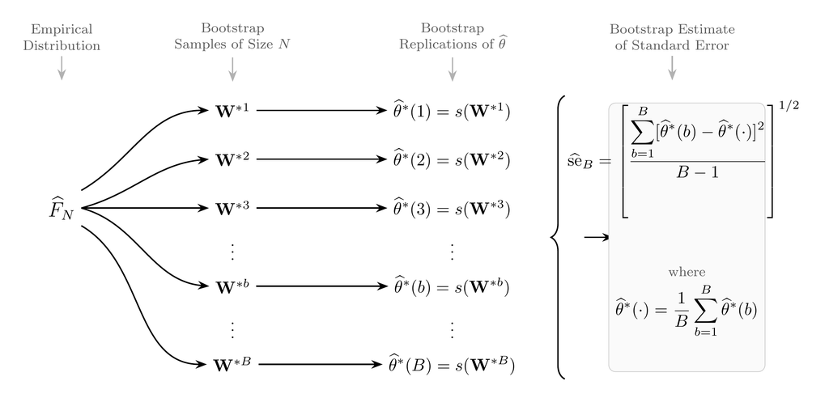

- Create $B$ bootstrap samples, each constructed by drawing from original sample with replacement $n$ times.
- Compute bootstrap replication $\widehat \theta_n^*(b)$ on each bootstrap sample.
- Define bootstrap s.e. for $\widehat \theta_{n}$ by
  $$\widehat{\text{se}}_B=\text{s.d.}(\widehat \theta_n^*(1),\widehat \theta_n^*(2),…,\widehat\theta^*_{n}(B))$$

## Normal Approx. Bootstrap CI

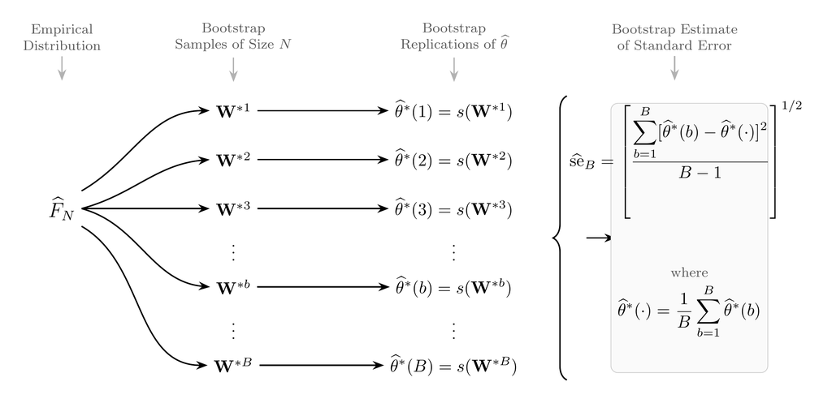

Given bootstrap standard error, $\widehat{\text{se}}_B$:

- Construct 95% normal-approximation bootstrap CI on $\theta$ by
  $$C^{nb} = [\widehat{\theta}_{n}-1.96 \cdot \widehat{\text{se}}_B, ~\widehat{\theta}_{n}+1.96 \cdot \widehat{\text{se}}_B]$$
- More generally, construct $1-\alpha$ level normal-approximation bootstrap CI on $\theta$ by
  $$[\widehat{\theta}_{n}- z_{1-\alpha/2} \cdot \widehat{\text{se}}_B, ~\widehat{\theta}_{n}+z_{1-\alpha/2} \cdot \widehat{\text{se}}_B]$$
  where $z_{1-\alpha/2}$ is the $1-\alpha/2$ quantile of standard normal distribution.

## Bootstrap Estimate of Bias

- Before turning to other CI methods, note that the bootstrap also estimates bias.
- Given $B$ bootstrap replications, define the bootstrap estimate of bias by
  $$\widehat{\text{bias}}^*= \left(\frac{1}{B} \sum_{b=1}^B \widehat \theta_n^*(b)\right) - \widehat \theta_{n}$$
  where $\widehat \theta_{n}$ is estimate from original sample.
- Why centered at $\widehat \theta_{n}$? The key idea: $\widehat \theta_{n}$ plays the role of the true parameter *in the bootstrap world*, just as $\theta_0$ is the true parameter in the original world.

## Algorithm for Percentile CI

- Given $B$ bootstrap replications, define $q^*_{\alpha}$ as the $\alpha$ empirical quantile of $(\widehat \theta_n^*(1),\widehat \theta_n^*(2),…,\widehat\theta^*_{n}(B))$
  - compute $q^*_{\alpha}$ as the smallest value such that at least a fraction $\alpha$ of the bootstrap replications are less than or equal to it.
- Bootstrap Percentile CI:
  $$C^{pc}= [q^*_{\alpha/2},~ q^*_{1-\alpha/2}].$$
- Uses quantiles of the bootstrap distribution as proxies for quantiles of sampling distribution of $\widehat \theta_{n}$.

## From Recipes to Theory

- We now have two bootstrap CI methods: bootstrap s.e. / normal CI and percentile CI.
- **Key questions:**
  - When does the bootstrap *work* — i.e., when does the bootstrap distribution approximate the true sampling distribution?
  - When does it *fail*?
  - Which CI method should we prefer for a given problem?
- To answer these, we need to understand what “the bootstrap works” means.

# Bootstrap Theory

## The Bootstrap World

- Let $F$ denote the true (unknown) CDF of $W_i$.
- The **empirical CDF** is
  $$\widehat F_{n}(t) = \frac{1}{n}\sum_{i=1}^n \mathbf{1}\{W_i \le t\}.$$
- In the **bootstrap world**, we draw $W_1^*, \ldots, W_{n}^* \stackrel{iid}{\sim} \widehat F_{n}$, i.e., sample *with replacement* from $(W_1, \ldots, W_{n})$.
- **Two sources of randomness to keep distinct:**
  - Randomness *in the bootstrap world*: randomness over resampling with the original sample held fixed.
  - Randomness *in the original world*: randomness of draws of $(W_1,\ldots,W_{n})$ from $F$.

## Bootstrap vs. Original World: Notation

The $*$ superscript always means “in the bootstrap world”:

|  | Original World | Bootstrap World |
| --- | --- | --- |
| **Data** | $W_1, \ldots, W_n \sim F$ | $W_1^*, \ldots, W_n^* \sim \widehat F_n$ |
| **Estimator** | $\widehat\theta_n = s(W_1,\ldots,W_n)$ | $\widehat\theta_n^* = s(W_1^*,\ldots,W_n^*)$ |
| **True parameter** | $\theta_0$ | $\widehat\theta_n$ |
| **Expectation** | $\mathbb{E}[\cdot]$ (over draws from $F$) | $\mathbb{E}^*[\cdot]$ (over resampling, sample fixed) |
| **Variance** | $\operatorname{Var}(\cdot)$ | $\operatorname{Var}^*(\cdot)$ |

- $\mathbb{E}^*[\cdot]$ and $\operatorname{Var}^*(\cdot)$ are computed holding the original sample fixed — they describe the variability due to resampling alone.
- Because they depend on which sample you happened to draw, bootstrap quantities like $\mathbb{E}^*[\widehat\theta_n^*]$ and $\operatorname{Var}^*(\widehat\theta_n^*)$ are themselves **random** from the perspective of the original world.

## Two Limits to Keep Straight

- Keep three objects distinct:
  - $G_n(\cdot,F)$ = true sampling distribution,
  - $G_n(\cdot,\widehat F_n)$ = exact bootstrap distribution,
  - $\widehat G_{n,B}(\cdot,\widehat F_n)$ = empirical distribution from the $B$ bootstrap replications.
- $B \to \infty$: for any fixed sample, $\widehat G_{n,B}(\cdot,\widehat F_n)\to G_n(\cdot,\widehat F_n).$ This just eliminates MC simulation error (LLN applied to the bootstrap simulation itself).
- $n \to \infty$: the substantive question is whether $G_n(\cdot,\widehat F_n)\approx G_n(\cdot,F).$ This is the real bootstrap validity question.
- In practice, we choose $B$ large enough that MC error is negligible, and rely on $n \to \infty$ theory to justify the approximation.

## Bootstrap CLT and Delta Method

There are bootstrap analogs to the CLT, CMT, and delta method. For example:

**Theorem: Bootstrap CLT**

Let $W_1, \ldots, W_{n}$ be i.i.d. with mean $\mu \in \mathbb{R}^k$ and covariance matrix $\Sigma$ positive definite. Then, as $n \rightarrow \infty$,
$$\sqrt{n}(\bar{W}_{n}^* - \bar{W}_{n}) \xrightarrow{d} N(0,\Sigma).$$

- The bootstrap distribution of $\sqrt{n}(\bar{W}_{n}^* - \bar{W}_{n})$ converges in bootstrap distribution to the *same* $N(0,\Sigma)$ limit as $\sqrt{n}(\bar{W}_{n} - \mu)$.

**Why center at the sample mean, not the population mean?**

In the bootstrap world, $\mathbb{E}^*[W_i^*] = \bar{W}_{n}$, so that the natural centering for the CLT is $\bar{W}_{n}$, not $\mu$.

## Bootstrap CLT and Delta Method (Cont’d)

There are bootstrap analogs to the CLT, CMT, and delta method. For example:

**Theorem: Bootstrap Delta Method**

If $\widehat \theta_{n} \xrightarrow{p} \theta_0$ and $\sqrt{n}(\widehat \theta_{n}^* - \widehat \theta_{n}) \xrightarrow{d} N(0,\sigma^2)$ as $n \rightarrow \infty$, and if $g: \mathbb{R} \to \mathbb{R}$ is continuously differentiable at $\theta_0$, then, as $n \rightarrow \infty$,
$$\sqrt{n}(g(\widehat \theta_{n}^*) - g(\widehat \theta_{n})) \xrightarrow{d} N(0, (g'(\theta_0))^2 \sigma^2)$$
where $g'(\theta_0)$ is the derivative of $g$ at $\theta_0$.

- The bootstrap distribution of $\sqrt{n}(g(\widehat \theta_{n}^*) - g(\widehat \theta_{n}))$ converges in bootstrap distribution to the *same* $N(0, (g'(\theta_0))^2 \sigma^2)$ limit as $\sqrt{n}(g(\widehat \theta_{n}) - g(\theta_0))$.
- Note centering at $g(\widehat \theta_{n})$ in the bootstrap world, not at $g(\theta_0)$.

## Bootstrap Consistency

The bootstrap is **consistent** for the distribution of $\widehat\theta_{n}$ if the bootstrap distribution converges to the same limit distribution as the original estimator:
$$Z_{n} = a_{n}(\widehat\theta_{n} - \theta_0) \xrightarrow{d} \zeta
\quad \text{and} \quad
Z_{n}^* = a_{n}(\widehat\theta_{n}^* - \widehat\theta_{n}) \xrightarrow{d} \zeta,$$
for the same limit $\zeta$.

In many applications, $a_{n} = \sqrt{n}$ and $\zeta \sim N(0,V)$.

More generally, the bootstrap is **consistent** for the distribution of estimators that are **smooth functions** of sample means.

## Distribution vs. Moment Consistency

- Bootstrap consistency says the *shape* of the bootstrap distribution converges to the right limit.
- But this does **not** automatically imply convergence of *moments*. In particular, it does not guarantee that the bootstrap variance converges to the true variance.
- To go from convergence in distribution to convergence in moments, we need an additional condition.

## Sufficient Condition for Convergence of Bootstrap Variance

**Theorem: Convergence of Bootstrap Variance**

If
$$Z_n^* = \sqrt{n}(\widehat\theta_n^* - \widehat\theta_n) \xrightarrow{d} N(0,V)$$
and the bootstrap distribution has a bounded $(2+\delta)$th moment for some $\delta > 0$, then
$$\operatorname{Var}^*(\sqrt{n}(\widehat\theta_n^* - \widehat\theta_n)) \xrightarrow{p} V.$$

This ensures the bootstrap s.e. converges to the right limit.

**Note:** Bootstrap quantities like $\operatorname{Var}^*(\cdot)$ are computed conditional on the original sample, so they depend on which sample you happened to draw. The bounded moment condition asks that this moment stays well-behaved for typical samples — which can fail when some bootstrap replications produce extreme values (e.g., from dividing by a near-zero $\widehat\beta_2^*$).

## Bootstrap s.e. Can Be Invalid

- **Without the bounded moment condition:** bootstrap s.e. can be unstable or even infinite, even when the bootstrap distribution is consistent.
- Distributional consistency controls the *shape* of the bootstrap distribution, but not the tails needed for second-moment convergence.

**Example:** For $p \in (0,1)$, the bootstrap is consistent for the distribution of $\sqrt{n}(1/\hat{p}_n - 1/p)$. But the bootstrap second moment can be infinite: when a bootstrap sample has $\hat{p}_n^* = 0$ (which occurs with positive probability), $1/\hat{p}_n^*$ is undefined, and the conditional bootstrap variance blows up.

This is the same phenomenon as the unstable running means for $1/\hat{p}$ in the MC simulation lectures.

## Bootstrap s.e.: Fragility

- This is why bootstrap s.e. can be *unreliable even when the bootstrap distribution is consistent*.
- The bootstrap s.e. $= \text{s.d.}(\widehat\theta^*_{n}(1), \ldots, \widehat\theta^*_{n}(B))$ is a sample standard deviation of the bootstrap replications.
- If the bootstrap second moment is infinite (or highly unstable), this s.d. is unstable across bootstrap simulations — exactly the running-mean instability from the MC lectures.
- **Implication for inference:** methods that rely on bootstrap s.e. (normal CI) are fragile to failures of second moments, while methods that use only bootstrap quantiles (percentile CI) avoid this particular problem.

## Bootstrap Normal CI: Asymptotic Coverage

**Theorem: Coverage of Bootstrap Normal CI**

If

1. $\sqrt{n}(\widehat\theta_n - \theta_0) \xrightarrow{d} N(0,V)$ (asymptotic normality), and
2. $\operatorname{Var}^*(\sqrt{n}(\widehat\theta_n^* - \widehat\theta_n)) \xrightarrow{p} V$ (consistent bootstrap variance),

then the bootstrap normal CI has correct asymptotic coverage:
$$P\!\left(\theta_0 \in [\widehat\theta_n \pm z_{1-\alpha/2} \cdot \widehat{\text{se}}_B]\right) \to 1 - \alpha.$$

- Requires **both** normality of the sampling distribution **and** consistent bootstrap s.e. (which in turn requires the bounded moment condition from the previous slide).

## Bootstrap Percentile CI: Asymptotic Coverage

**Theorem: Coverage of Bootstrap Percentile CI**

If

1. bootstrap consistency holds: $a_n(\widehat\theta_n - \theta_0)$ and $a_n(\widehat\theta_n^* - \widehat\theta_n)$ have the same continuous limit distribution, and
2. that limit distribution is **symmetric**,

then the bootstrap percentile CI has correct asymptotic coverage:
$$P\!\left(\theta_0 \in [q^*_{\alpha/2},\; q^*_{1-\alpha/2}]\right) \to 1 - \alpha.$$

- Does **not** require normality (just symmetry — weaker).
- Does **not** require consistent bootstrap s.e. or the bounded moment condition (uses quantiles, not variance).
- **Diagnostic:** performs poorly in finite samples when the sampling distribution of $\widehat\theta_n$ is highly asymmetric at the given $n$.

## Beyond First-Order: Finite-Sample Advantages

- As $n\to\infty$, the bootstrap distribution and the normal approximation are first-order asymptotically equivalent.
- But for any **finite** $n$, the bootstrap distribution is *not* exactly normal. It captures features of the true finite-sample distribution that the normal approximation misses:
  - **skewness** of $\widehat \theta_{n}$,
  - **bias** of $\widehat \theta_{n}$,
  - dependence of spread on the realized data.

## When Ordinary Nonparametric Bootstrap Fails

Standard bootstrap consistency can break down when:

1. **Non-smooth functionals**: e.g., $\widehat\theta_{n} = \max(W_1, \ldots, W_{n})$ — the maximum often converges at a rate other than $\sqrt{n}$, and the bootstrap gives the wrong limit distribution.
2. **Boundary of parameter space**: e.g., a variance component on the boundary in a random-effects model.
3. **Ill-conditioned derivatives**: if $\nabla g(\theta_0)$ is very large or unbounded (for example, a ratio with denominator near zero), delta-method and bootstrap approximations become unstable.
- **Preview of our application:** The ratio estimator $-\widehat \beta_{1,n} / 2\widehat \beta_{2,n}$ has derivative involving $1/\beta_2^2$. If $\beta_2$ is close to zero, this explodes, and the bootstrap distribution becomes erratic. We will see this in the next lecture.

## Summary

- The bootstrap approximates the sampling distribution by resampling from $\widehat F_n$.
- Bootstrap consistency (distributional) holds for smooth functions of sample means.
- Distributional consistency does **not** imply moment convergence — bootstrap s.e. can be unreliable even when the bootstrap distribution is consistent.
- The **normal CI** relies on normality *and* consistent bootstrap s.e. — it is fragile when either fails.
- The **percentile CI** uses only quantiles — it avoids the moment problem, but requires approximate symmetry of the sampling distribution.
- **Next lecture:** application to Mincer wage equation, bootstrap hypothesis testing, and the wild bootstrap.